# Dynamic control of enhancer activity drives stage-specific gene expression during flower morphogenesis | Nature Communications

# Dynamic control of enhancer activity drives stage-specific gene expression during flower morphogenesis

- Wenhao Yan ,
- Dijun Chen <sup>,</sup>,
- Julia Schumacher <sup>,</sup>,
- Diego Durantini,
- Julia Engelhorn,
- Ming Chen,
- Cristel C. Carles &
- …
- Kerstin Kaufmann

[*Nature Communications*](https://www.nature.com/ncomms) **volume 10**, Article number: 1705 (2019) Cite this article

## Abstract

Enhancers are critical for developmental stage-specific gene expression, but their dynamic regulation in plants remains poorly understood. Here we compare genome-wide localization of H3K27ac, chromatin accessibility and transcriptomic changes during flower development in *Arabidopsis*. H3K27ac prevalently marks promoter-proximal regions, suggesting that H3K27ac is not a hallmark for enhancers in *Arabidopsis*. We provide computational and experimental evidence to confirm that distal DNase І hypersensitive sites are predictive of enhancers. The predicted enhancers are highly stage-specific across flower development, significantly associated with SNPs for flowering-related phenotypes, and conserved across crucifer species. Through the integration of genome-wide transcription factor (TF) binding datasets, we find that floral master regulators and stage-specific TFs are largely enriched at developmentally dynamic enhancers. Finally, we show that enhancer clusters and intronic enhancers significantly associate with stage-specific gene regulation by floral master TFs. Our study provides insights into the functional flexibility of enhancers during plant development, as well as hints to annotate plant enhancers.

[figure not shown]

[figure not shown]

[figure not shown]

## Introduction

Multicellular development is controlled by precise spatiotemporal regulation of gene expression, which is largely accomplished through the activation and repression via *cis*-regulatory elements within the promoter-proximal or distal regulatory regions, such as enhancers. Promoters and enhancers are noncoding DNA sequences that can be bound by multiple regulatory proteins, especially transcription factors (TFs) to activate the expression of target genes<sup>1</sup>. Active promoters and enhancers are devoid of nucleosomes, thereby rendering the DNA accessible for TF binding. While promoters locate near the transcription start site (TSS), enhancers can be up to several Mbs away from their target genes<sup>1</sup>. A single gene can be regulated by multiple enhancers with different spatiotemporal activities, resulting in a large combinatorial complexity of expression repertoires for a given set of genes<sup>2</sup>. Large-scale analyses in animal genomes showed that promoters and enhancers are distinguishable based on their stereotypical DNA features and chromatin signatures<sup>3</sup>. For example, enhancers are often associated with mono-methylation of H3 at lysine 4 (H3K4me1) and H3 acetylation marks at lysine 9 and 27 (H3K9ac and H3K27ac)<sup>4</sup>, while gene promoters differ from enhancers by their enrichment in H3K4me3<sup>3</sup>. On the other hand, there is an increasing number of reports<sup>5,6</sup> showing that promoters and enhancers share similar structural and functional features<sup>1</sup>.

Enhancers have recently been subjected to intensive investigation as there is increasing evidence showing their importance not only in developmental control but also in evolution and diseases, including cancer<sup>2</sup>. The advent of next-generation sequencing technologies and the identification of enhancer chromatin properties enable genome-wide prediction of enhancers in a high-throughput manner<sup>3</sup>, leading to the discovery of thousands of enhancer candidates in human<sup>6,7</sup> and other animal genomes<sup>8</sup>. Enhancers appear to function as integrated platforms for binding of multiple TFs, often including lineage- and signal-determining (intrinsic or extrinsic cue-dependent signal) TFs<sup>2,9</sup>. Remarkably, cell identity gene loci are frequently associated with dense clusters of enhancers or super-enhancers with both overlapping and distinct spatiotemporal activities<sup>10,11</sup>. Genome-wide analyses of enhancer functions have revealed that enhancers are functionally complex and developmentally dynamic during cell differentiation<sup>12</sup>. Lineage-regulating factors, including pioneer factors and their associated TF networks, contribute to shaping enhancer repertoires during development<sup>12,13,14</sup>.

Contrary to the fast growing knowledge of the regulatory function of enhancers in metazoans, knowledge of genome-wide landscapes of plant enhancers and their dynamic activities remains limited in the context of developmental stage-specific gene regulation<sup>15</sup>. Enhancers are predominantly found in regions of accessible chromatin<sup>3</sup>, which is more sensitive to DNase I digestion than condensed chromatin. Genome-wide mapping of open chromatin regions has been conducted in the selected model and crop plant species<sup>16,17,18,19,20,21</sup>. In 2012, Zhang et al. reported the mapping of open chromatin in rice seedlings and callus using DNase-seq. They found that DNase I hypersensitivity sites (DHSs) are associated with highly expressed genes in both tissues, and that 42.3% and 44.5% of DHSs in seedlings and in calli, respectively, reside in intergenic regions<sup>16</sup>. The same group later identified a high overlap between TF occupancy and DHSs in *Arabidopsis thaliana* leaves and flowers and they found that around 90% of APETALA1 (AP1) and SEPALLATA3 (SEP3) binding sites overlap with DHSs<sup>17</sup>. Using these above-mentioned open chromatin signatures, they further carried out a genome-wide prediction and validation of *Arabidopsis thaliana* intergenic enhancers<sup>20</sup>. A total of 10,044 intergenic DHSs were identified as putative enhancers, of which 1644 and 2529 are leaf- and flower-tissue specific, respectively. Enrichment of both H3K27ac and H3K27me3 was reported in the genomic regions of predicted tissue-specific enhancers, with a positive correlation for H3K27ac and a negative correlation with H3K27me3<sup>20</sup>. More recently, by combining the information of genome-wide DNA methylation, chromatin accessibility, and H3K9ac profiling, 1500 intergenic enhancers were predicted in maize<sup>21</sup>. Although these studies spark the renewed interest in the investigation of plant enhancer elements, genome-wide mechanisms of dynamic enhancer activities to trigger spatiotemporal gene expression in plant development have not yet been elucidated.

Here, we used flower development as an ideal system to study enhancer dynamics and to dissect their roles in the control of stage-specific gene expression patterns by integrative analysis of genome-wide H3K27ac locations (ChIP-seq), chromatin accessibility (DNase-seq)<sup>18</sup>, and transcriptome dynamics (RNA-seq) in *Arabidopsis thaliana* at four representative stages. We found that H3K27ac prevalently marks promoters but rarely localizes in distal regulatory regions, suggesting that H3K27ac is not a hallmark for active enhancers in *Arabidopsis thaliana* as it is in metazoans<sup>22</sup>, and as data from rice and maize indicate<sup>23,24</sup>. Examination of DHS-predicted distal intergenic enhancers reveals their high-stage specificity across flower development, their functional importance in the regulation of flowering genes, as well as their high evolutionary conservation across crucifer and dicot species.

## Results

### Distribution of H3K27ac and DHSs during flower development

**Fig. 1**

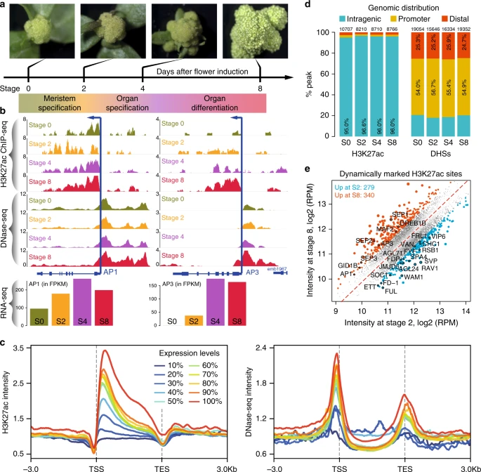

Genome-wide mapping of DHSs and H3K27ac sites across flower development. **a** Schematic representation of the floral induction system (pAP1::AP1-GR *ap1 cal*) for collecting synchronized flower tissues at four key developmental stages (stage 0, stage 2, stage 4, and stage 7/8). **b** Genome browser tracks (colored according to stages) showing H3K27ac binding signal (measured by ChIP-seq) and chromatin accessibility (by DNase-seq) around the *AP1* (left) and *AP3* (right) loci. The expression levels of these two genes measured by RNA-seq are shown in the barcharts below. FPKM, fragments per kilobase of transcript per million mapped reads. S0, stage 0. **c** The relationship between H3K27ac binding signals (left) or chromatin accessibility (right) and the levels of gene expression at stage 8. In the analysis, the expressed genes were equally divided into 10 groups (*n* = 2083 genes in each group) from low expression (10%) to high expression (100%) based on the expression levels. Mean-normalized ChIP-seq or DNase-seq densities were plotted within a 6-kb region flanking the transcription start site (TSS) or the transcription end site (TES) for each groups of genes. **d** Stacked bar plot showing the distribution of H3K27ac peaks and DNase I hypersensitive sites (DHSs) in different genomic regions at 0, 2, 4, and 8 DAI. Promoters are defined as genomic regions encompassing 1 kb upstream of the TSS. Distal intergenic regions are genomic regions except intragenic and promoter regions. Peaks were assigned to each category based on their summits. **e** Comparison of H3K27ac enrichment at stages 2 and 8 of flower development. Each point represents an H3K27ac enriched region. Regions showing more than 1.5-fold difference of enrichment are indicated in blue (more enrichment at S2) and red (more enrichment at S8). Numbers indicate the number of target genes. Examples of target genes (with black circles) are labeled. The underlying source data for **d** and **e** are provided in the Source Data file

[Full size image](https://www.nature.com/articles/s41467-019-09513-2/figures/1)

We observed that most of the H3K27ac sites are located in intragenic regions and directly downstream of the TSS (Fig. 1c, d—left panels; Supplementary Fig. 5a, b). In detail, out of all the high-quality H3K27ac peaks identified at different developmental stages (Supplementary Data 1), more than 95% were found in gene bodies, whereas only about 2.5% were mapped to distal intergenic regions (> 1 kb from the TSS; Fig. 1d—left panel). In contrast, the majority (~80%) of DNase I hypersensitivity sites (DHS) were found in intergenic regions and they clearly resided upstream of the TSS (Fig. 1c, d—right panels; Supplementary Fig. 5c, d). Interestingly, DNA-binding sites of floral regulatory TFs highly overlap with DHSs, but not with H3K27ac sites (Supplementary Fig. 6). However, the distance of binding sites to their closest H3K27ac peaks varies for different regulators (Supplementary Fig. 6a). Given that H3K27ac mainly marks TSS-proximal regions, the above observation indicates that different TFs have different binding preferences in genomic locations with respect to the TSS. Furthermore, we found that although most H3K27ac sites remained stably enriched during flower development (Supplementary Fig. 7), 23.2% (2913/12579) of them displayed at least a 1.5-fold change in H3K27ac peak intensity among the four time points. These 2913 sites were classified into four clusters based on their dynamic behavior (Supplementary Fig. 8a–c, Supplementary Data 2). Generally, the dynamics of H3K27ac and changes in gene expression showed a positive correlation in each cluster (Supplementary Fig. 8c). The occasionally observed differences between changes in H3K27ac and in gene activities (e.g., for genes in groups 2 and 4; Supplementary Fig. 8c) can be partly explained by the fact that the data were not generated from individual cells or cell types, but correspond to “average” signals from whole stage-specific meristems, or organ differentiation stages. For example, strong gene activation in some of the cells may be associated with an overall reduction in H3K27ac levels, if in most other cells, the gene is not activated or becomes repressed. Gene ontology (GO) enrichment analysis revealed that genes with dynamic H3K27ac activities were highly enriched in functions, such as “regulation of gene expression” and “flower development”-related processes (Supplementary Fig. 8d). We further compared H3K27ac ChIP-seq signal intensities between 2 and 8 DAI, two representative time points for early and late flower development (Fig. 1e). There are 279 genes showing elevated H3K27ac levels at 2 DAI, including several known MADS-box genes, such as *FRUITFULL* (*FUL*), *SHORT VEGETATIVE PHASE* (*SVP*), *SUPPRESSOR OF OVEREXPRESSION OF CONSTANS1* (*SOC1*), and *AGAMOUS-LIKE 24* (*AGL24*), which are important for floral transition and initiation<sup>29</sup>. Another set of 340 genes showed higher H3K27ac signals and increased expression levels at 8 DAI, including floral organ identity genes *AP3* and *SEPALLATA* (*SEP1*, *SEP2*, and *SEP3*). In summary, we found that H3K27ac is highly associated with gene activity during flower development. Together, our results support and refine previous research<sup>20</sup>, showing that H3K27ac is highly correlated with gene activation during floral meristem and organ development. In addition, the difference in localization of H3K27ac sites and DHSs with respect to the TSS in distal intergenic regions indicates that they may activate gene expression via distinct mechanisms.

### H3K27ac is not a hallmark of enhancers in Arabidopsis

Recent work suggested that H3K27ac colocalizes with distal intergenic DHSs in *Arabidopsis thaliana*, indicating that this mark associates with enhancer elements<sup>20</sup>. However, we identified very few distal intergenic H3K27ac peaks (Supplementary Data 1). This difference with the previous study led us to re-examine the use of H3K27ac as a mark to map distal regulatory regions (such as enhancers) in *Arabidopsis thaliana*. We found that <3% of H3K27ac sites mapped outside core promoters (within 1 kb upstream of the TSS) and transcribed regions (with a peak summit >1 kb away from the TSS site; Fig. 1d). This observation is in line with the percentage reported in seedlings<sup>25</sup>. In contrast, ca. 25% of the DHSs were found in distal intergenic regions. Consistently, the center of most (>95%) H3K27ac peaks are present in intragenic regions (Fig. 1d), and these intragenic H3K27ac sites locate at ~300 bp (median value) downstream of the TSS (Fig. 2a). The centers of intragenic DHSs preferentially locate around 1 kb away from the TSS (Fig. 2b), while the centers of intergenic DHSs locate in both promoter-proximal (~120 bp upstream of the TSS, median value) and distal regions (~1.6 kb upstream of the TSS, median value; Fig. 2c), respectively. We further determined the distance between DHSs and H3K27ac peaks. Interestingly, we found that nearly all the H3K27ac sites resided within 1 kb from a nearby DHS in all four stages (Supplementary Fig. 9a). In contrast, a considerable proportion of DHSs appeared to be isolated more than 1 kb apart from H3K27ac sites (Supplementary Fig. 9b, c). These findings were further supported by the observation that the flanks of proximal DHSs were largely enriched in H3K27ac modification, while the flanks of distal intergenic DHSs showed no enrichment in H3K27ac (Supplementary Fig. 10). These observations are contradictory to the former report from Zhang et al., where the authors found H3K27ac enrichment surrounding enhancer regions using data generated from leaf and mixed flower tissues in *Arabidopsis thaliana*<sup>20</sup>. We thus reanalyzed these previously published H3K27ac and DNase-seq data and reached conclusions similar to those we obtained from the flower developmental time-series data (Supplementary Fig. 11), indicating that the discrepancy is not due to different tissues used or datasets generated. The differences between our report and that of Zhang et al. likely result from the differences in the sizes of regions chosen for the analysis (5 kb in Zhang et al.<sup>20</sup> vs. 1 kb in our study). 5 kb enhancer flanking regions may overlap with the H3K27ac signal from distal sites, because the *Arabidopsis thaliana* genome is very compact with an average size of ~3 kb for intergenic regions. In summary, these results indicate that, at least in *Arabidopsis thaliana*, H3K27ac is not a suitable mark to predict active distal regulatory elements (including enhancers), because the majority of H3K27ac sites appear in intragenic or promoter regions and hardly coexist with DHSs in distal intergenic regions.

**Fig. 2**

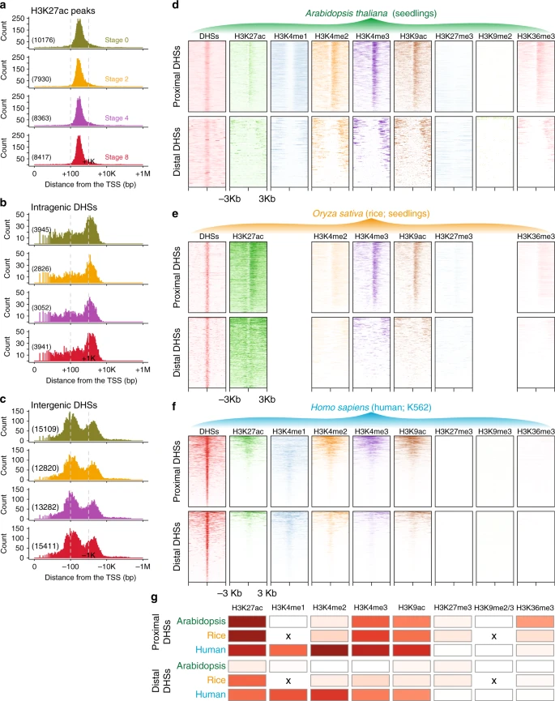

H3K27ac preferentially appears in promoter regions but not in enhancers in Arabidopsis. **a** Distribution of the distance of H3K27ac peak summits from the transcription start site (TSS). Only intragenic H3K27ac peaks were used in the analysis. **b**, **c** Distribution of the distance of the center of DNase I hypersensitive sites (DHSs) from the TSS. Intragenic DHSs are downstream of the TSS (**b**), while intergenic DHSs are upstream of the TSS (**c**). **a**–**c** The number of H3K27ac peaks or DHSs is shown in parentheses. Note that the distance for intragenic peaks is presented as positive (+) values, while the distance for intergenic peaks is shown as minus (–). The *x* axis is log10-transformed. **d**–**f** Various histone modification ChIP intensities relative to the peak centers of proximal and distal DHSs. ChIP-seq and DNase-seq data were generated from Arabidopsis seedlings (**d**), rice seedlings (**e**), and human K562 cell line (**f**). Note that there is no H3K36me3 enrichment at the gene body at the proximal DHSs in the human cell line. This is in contrast to other reports in mammals (e.g., ref. <sup>81</sup>), possibly due to differences in H3K36me3 antibody quality. **g** Relative enrichment of selected histone modifications in proximal and distal DHSs, respectively. The heatmap shows the Jaccard statistic between the intervals of DHSs and histone-modified sites. “x” denotes the missing matched histone modification datasets in rice. High values are shown in red and low values in white. The underlying source data for **a**, **b**, and **g** are provided in the Source Data file

[Full size image](https://www.nature.com/articles/s41467-019-09513-2/figures/2)

To further investigate whether other histone modifications are hallmarks of enhancers annotated by distal DHSs, we extended our analyses by using a large catalog of histone modifications, including H3K27ac, H3K4me1, H3K4me2, H3K4me3, H3K9ac, H3K9me2, H3K27me3, and H3K36me3, for which datasets were generated from *Arabidopsis thaliana* seedlings<sup>20,30</sup> (Fig. 2d). We believe that the general distribution patterns of DHSs with respect to histone marks are comparable among different tissues, since we observed similar distribution patterns of H3K27ac with respect to DHSs between seedlings and flowers (Supplementary Figs. 9, 11). In the analysis, enrichment of each histone modification was plotted relative to the peak centers of proximal and distal DHSs, respectively. Moreover, to avoid bias due to the strategy used in our analysis and to compare our findings in different species, we applied the same methodology to matched datasets in rice (*Oryza sativa*) seedlings<sup>16,23,31</sup> (Fig. 2e) and in the human (*Homosapiens*) K562 cell line<sup>6</sup> (Fig. 2f). We found that H3K27ac, H3K4me3, and H3K9ac, known features for promoter annotation<sup>3,32</sup>, are conserved marks to predict proximal DHSs in all the three investigated species (Fig. 2d–g; Supplementary Fig. 12). The distal DHSs were largely occupied by surrounding H3K27ac in human and in rice genomes. However, the *Arabidopsis thaliana* distal DHSs barely exhibited H3K27ac modification in their flanks. Strikingly, none of the investigated histone modifications coexisted with distal DHSs in our study, and thus none of them could be considered as chromatin signatures to predict enhancers in *Arabidopsis thaliana* (Fig. 2g). Taken together, unlike the findings in humans and rice, our results imply that H3K27ac is not a hallmark for enhancer annotation in *Arabidopsis thaliana*.

### Distal DHS sites are predictive of enhancers

**Fig. 3**

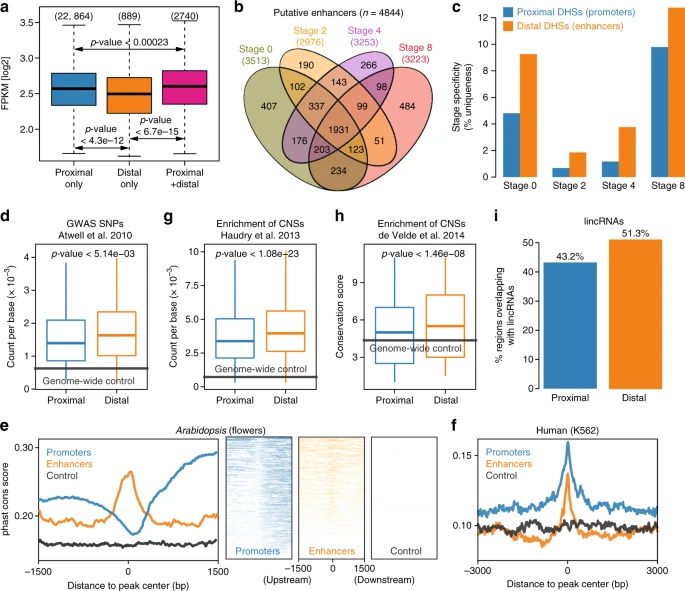

Identifying and characterizing intergenic DHS-based enhancers. **a** Boxplots of gene expression for H3K27ac-marked genes associated with only proximal DNase I hypersensitive sites (DHSs), with only distal DHSs, or with both. *P*-values were calculated based on Wilcoxon signed-rank tests. The number of genes in each category is shown in parentheses. **b** Venn diagram representing the overlap of putative enhancers identified in different stages. **c** Bar chart showing the stage specificity, i.e., the called DHSs only existed at one specific stage, of promoters and distal enhancers. **d** Enrichment of significant associations for flowering-related phenotypes from a genome-wide association study (GWAS)<sup>37</sup>. The *y* axis shows the number of significant SNPs per basepair. **e** Distribution of phastCons score around the peak centers of promoter (blue) and enhancer (orange) DHSs in Arabidopsis. The distribution of phastCons score for promoter and enhancer DHSs was plotted in a strand-specific manner, using the orientation of their target genes. As a control, 10,000 random intergenic non-DHS regions were used to calculate the distribution of phastCons score (gray). PhastCons scores between Arabidopsis and other crucifers were taken from ref. <sup>38</sup> for Arabidopsis (nine-way multiple alignment). Left panel, composite (average intensity) plots; right panel, heatmaps of conservation distribution per DHS. **f** Similar to **e** (left panel), conversation analysis of human promoter and enhancer DHSs in the K562 cell line. PhastCons scores for humans were taken from the UCSC genome browser (100-way multiple alignment). **g** Enrichment of conserved noncoding sequences (CNSs) in promoters and enhancers. The y axis shows the number of CNSs per basepair. Data from ref. <sup>38</sup>. **h** Similar to **g**, the *y* axis shows the conservation score. Data from ref. <sup>40</sup>. **a**, **d**, **g**, **h** Boxplots show the median (horizontal line), second to third quartiles (box), and Tukey-style whiskers (beyond the box). **d**–**h** Genome-wide average values were used for control (gray lines). *P*-values measure statistical significance based on a Welch’s t test. **i** Percentage of promoters and enhancers overlapping with lincRNA loci. Annotation of lincRNAs were obtained from refs. <sup>41, 42</sup>. The underlying source data for **a**, **c**, **d**, and **g**–**i** are provided in the Source Data file

[Full size image](https://www.nature.com/articles/s41467-019-09513-2/figures/3)

### Validation of the predicted enhancers

**Fig. 4**

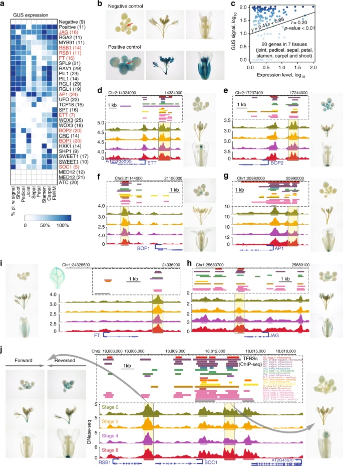

Functional validation of predicted enhancers in flower development via GUS reporter assay. **a** Heatmap showing GUS signals in different flower organs (columns) of T1 transgenic lines transformed with different enhancer constructs (rows). White indicates that no GUS expression was detected in any plants. Blue color intensity refers to the percentage of transgenic plants with detectable GUS expression. Names of genes that are proximal to the candidate enhancers are labeled on the right side and the numbers in parentheses represent the number of independent transgenic lines generated from the construct. Red, examples shown in **d**–**j**. Bold, the corresponding enhancer was validated with two independent constructs; underlined, construct that contains a reverse-orientated enhancer fragment. **b** Pictures of a dissected inflorescence, including a central inflorescence meristem (red arrow) and the surrounding young floral buds, of a whole inflorescence, and of a mature flower (from left to right, respectively) from plants harboring mimial35S as a negative control (left panel) or an enhancer element for a 35S promoter as a positive control (right panel). **c** Pearson correlation (*r*) between GUS signals and expression profiles of the corresponding genes in the tested tissues. Tissue-specific gene expression data can be found in Supplementary Data 4. Data points were colored according to the GUS signals in **a**. **d**–**j** Genome browser view of DHS signal profiles as well as called DHS peaks (horizontal bars below the signal profile), and transcription factor binding sites (TFBSs; data from ref. <sup>48</sup>) at the genomic region of predicted enhancers (in yellow-background boxes). Pictures of a dissected inflorescence, including a central inflorescence meristem and the surrounding young floral buds, of a whole inflorescence, and of a mature flower (from top to bottom, respectively) on the left or right of the genome browser view represent transgenic lines harboring the corresponding enhancer construct. The proximal genes of selected enhancers showed here are *ETT* (**d**), *BOP2* (**e**), *BOP1* (**f**), *AP1* (**g**), *JAG* (**h**), *FT* (**i**), and *RSB1* and *SOC1* (**j**). Color legends for the tracks are indicated in **j**. Note that the validated enhancers for genes *JAG* (**h**), *FT* (**i**), and *RSB1* or *SOC1* (**j**) are located downstream of the genes. The underlying source data for **a** and **c** are provided in the Source Data file

[Full size image](https://www.nature.com/articles/s41467-019-09513-2/figures/4)